# Distribution Note

```r
library(tidyverse)
set.seed(255)
```

# 離散

## 幾何分布

単調減少する。

確率probのベルヌイ試行をしたとき何回目で初めて成功するか。

probが小さいほど裾が長い。

```r
x <- rgeom(100, prob = 0.3)

print(mean(x))
```

```
[1] 2.26
```

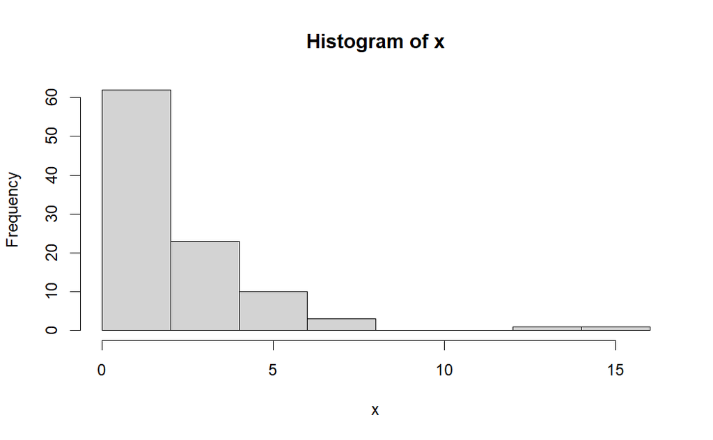

```r
hist(x)
```

平均はprobに反比例する。

```r
prob <- seq(0.1, 0.7, by = 0.1)
xlist <- map(prob, ~ rgeom(100, .))

tibble(prob = prob, mean = map_dbl(xlist, mean))
```

| prob | mean |
| --- | --- |
| 0.1 | 9.52 |
| 0.2 | 3.90 |
| 0.3 | 2.04 |
| 0.4 | 1.75 |
| 0.5 | 1.00 |
| 0.6 | 0.66 |
| 0.7 | 0.33 |

## ポワソン分布

平均lambdaの分布。一応分散もlambda。

平均lambdaで離散の正規分布みたいなイメージ。

上限は厳密にはないが、lambdaのだいたい倍ぐらい。

平均してlambda回発生する事象がk回発生する確率に相当する。

```r
x <- rpois(100, lambda = 3)

print(mean(x))
```

```
[1] 3.05
```

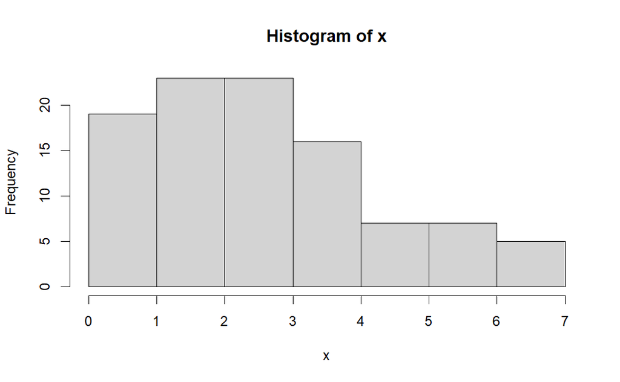

```r
hist(x)
```

# 連続

## ワイブル分布

平均はscale弱ぐらい(0.9かけぐらい)。下限は0。 scaleが大きくても小さくても平均の傾向は変わらない。

裾が垂れる方向はshapeで制御できる。

総じて裾の偏りを制御できる正規分布っぽい。

```r
x <- rweibull(1000, shape = 5, scale = 50)

mean(x)
```

```
[1] 45.50202
```

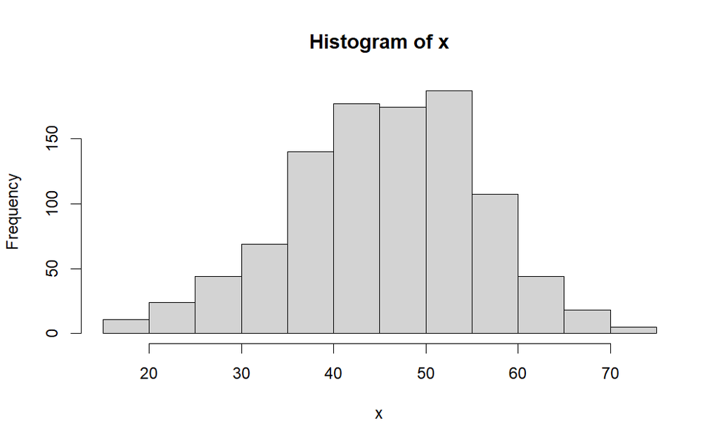

```r
hist(x)
```

```r
x <- rweibull(1000, shape = 2, scale = 50)

mean(x)
```

```
[1] 45.02352
```

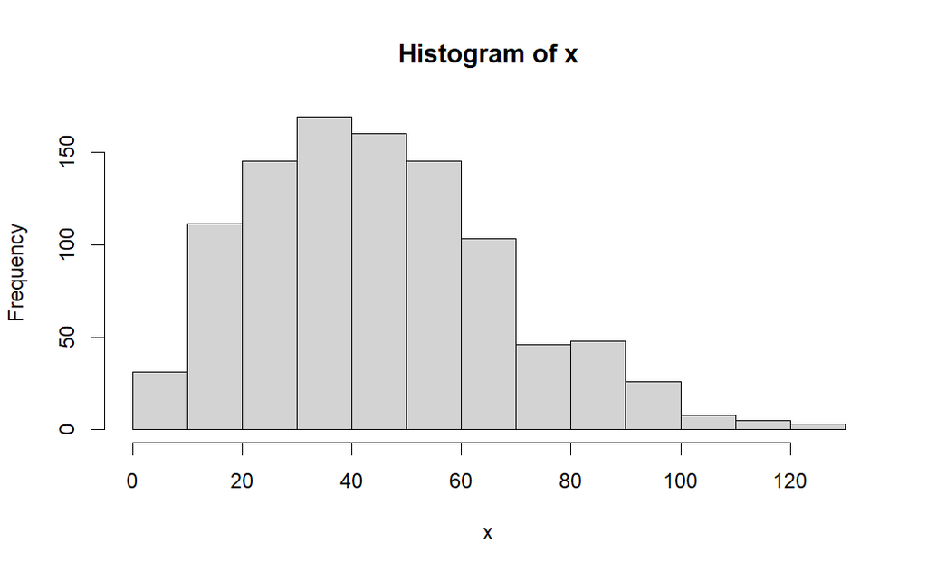

```r
hist(x)
```

```r
scale <- 10 ^ (-2:5)
xlist <- map(scale, ~ rweibull(1000, 3, .))

tibble(scale = scale, mean = num(map_dbl(xlist, mean), notation = "si"))
```

| scale | mean |
| --- | --- |
| 1e-02 | 9.21m |
| 1e-01 | 89.1 m |
| 1e+00 | 893. m |
| 1e+01 | 8.98 |
| 1e+02 | 87.8 |
| 1e+03 | 884. |
| 1e+04 | 8.87k |
| 1e+05 | 89.1 k |

## ベータ分布

0から1までの値をとる分布。

shape1とshape2の二つのパラメータはそれぞれ左右の裾の重さと対応する。 shapeが1以下の場合は単調減少(shape1)または単調増加(shape2)となる。

shape1と2が等しい場合は左右対称になる。 この場合shapeが大きいほど尖度が高くなる。

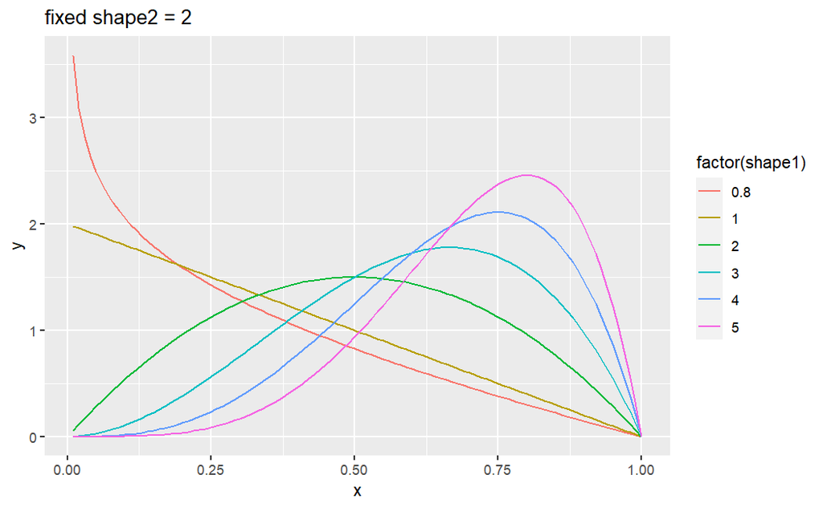

```r
x <- seq(0, 1, by = 0.01)
shape1 <- c(0.8, 1:5)
X <- expand_grid(x, shape1) %>%
  filter(x > 0) %>%
  mutate(y = dbeta(x, shape1, shape2 = 2))

ggplot(X, aes(x, y, color = factor(shape1))) +
  geom_line() +
  labs(title = "fixed shape2 = 2")
```

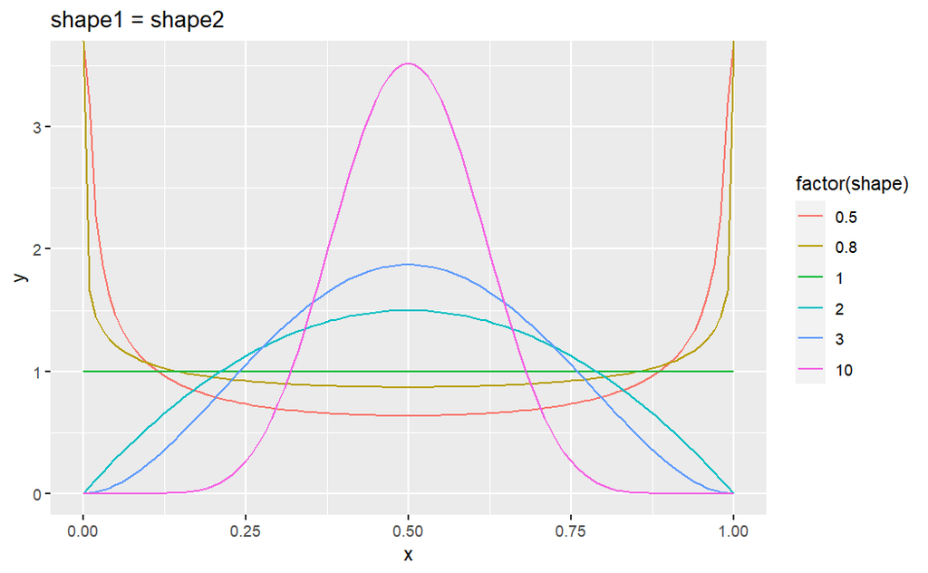

```r
x <- seq(0, 1, by = 0.01)
shape <- c(0.5, 0.8, 1:3, 10)
X <- expand_grid(x, shape) %>%
  mutate(y = dbeta(x, shape, shape))

ggplot(X, aes(x, y, color = factor(shape))) +
  geom_line() +
  labs(title = "shape1 = shape2")
```